# Chapter 4

jim108@gmx.net

5/16/2020

## 4E1.

In the model definition below, which line is the likelihood?
$$y_i \sim Normal(\mu, \sigma)\\
\mu \sim Normal(0,10)\\
\sigma \sim Exponential(1)$$

The first line.

## 4E2.

In the model definition just above, how many parameters are in the posterior distribution?

Count parameters = $\#\{\mu,\sigma\}=2$.

## 4E3.

Using the model definition above, write down the appropriate form of Bayes’ theorem that includes the proper likelihood and priors.
$$p(\mu, \sigma \mid y) = \frac{\prod_i Normal(y_i\mid\mu, \sigma) Normal(\mu\mid 0, 10) Exponential(\sigma\mid 1)}{\int\int \prod_i Normal(y_i\mid\mu, \sigma) Normal(\mu\mid 0, 10) Exponential(\sigma\mid 1) d\mu\, d\sigma}$$

## 4E4.

In the model definition below, which line is the linear model?
$$y_i \sim Normal(\mu_i, \sigma)\\
\mu_i = \alpha + \beta x_i\\
\alpha \sim Normal(0, 10)\\
\beta \sim Uniform(0, 1)\\
\sigma \sim Exponential(2)$$
The second line.

## 4E5.

In the model definition just above, how many parameters are in the posterior distribution?

Count parameters = $\#\{\alpha,\beta, \sigma\}=3$.

## 4M1.

For the model definition below, simulate observed y values from the prior (not the posterior).
$$y_i \sim Normal(\mu, \sigma)\\
\mu \sim Normal(0, 10)\\
\sigma \sim Exponential(1)$$

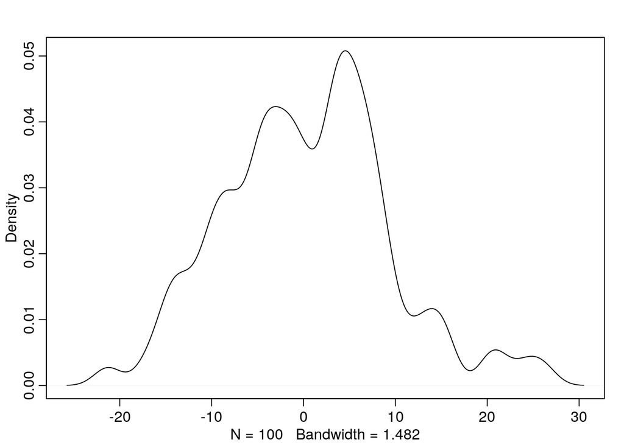

```r
n <- 100
mu <- rnorm(n,0,10)
sigma <- rexp(n,1)
y <- rnorm(n, mu, sigma)
dens(y)
```

## 4M2.

Translate the model just above into a quap formula.

```r
quap_formula <- alist(
  y ~ dnorm( mu, sigma),
  mu ~ dnorm( 0, 10),
  sigma ~ dexp(1)
)
```

## 4M3.

Translate the quap model formula below into a mathematical model definition.

```r
flist <- alist(
  y ~ dnorm( mu , sigma ),
  mu <- a + b*x,
  a ~ dnorm( 0 , 10 ),
  b ~ dunif( 0 , 1 ),
  sigma ~ dexp( 1 )
)
```

$$y_i \sim Normal(\mu_i, \sigma)\\
\mu_i = \alpha + \beta x_i\\
\alpha \sim Normal(0, 10)\\
\beta \sim Uniform(0, 1)\\
\sigma \sim Exponential(1)$$

## 4M3.

Given: Students measured for height for 3 years.

Want: Regression model for height.

Sol.:

$$h_i \sim Normal(\mu_i, \sigma)\\
\mu_i = \alpha + \beta(y_i - \bar{y})\\
\alpha \sim Normal(170, 10)\\
\beta \sim Log-Normal(0, 1)\\
\sigma \sim Uniform(0,10)$$

- The 95 % interval of height is set to $170\pm 20$cm for the average year ($\bar{y}:=\frac{0+1+2}{3}=1$).
- The 95 % interval for the increase in height per year is set to $\pm 20$cm per year.
- The Log-Normal distribution is choosen to keep $\beta$ positive.

## 4M4.

Given: 4M3 and every student got taller each year.

Want: Regression model for height.

Sol.:

Already incorporated.

## 4M5.

Given: 4M3 and the variance among heights for students of the same age is nevermore than 64cm.

Want: Regression model for height.

Sol.:

$$h_i \sim Normal(\mu_i, \sigma)\\
\mu_i = \alpha + \beta(y_i - \bar{y})\\
\alpha \sim Normal(170, 32)\\
\beta \sim Log-Normal(0, 1)\\
\sigma \sim Uniform(0,10)$$

## 4H1.

Given: Entire Howell1 data.

Want: Expected heights and 89 % interval for weights 46.95, 43.72, 64.78, 32.59, 54.63.

Sol.:

```r
#4H1
data("Howell1")
d <- Howell1

xbar <- mean(d$weight)
# fit model
m4H1 <- quap(
  alist(
    height ~ dnorm( mu , sigma ) ,
    mu <- a + b*( weight - xbar ) ,
    a ~ dnorm( 178 , 20 ) ,
    b ~ dlnorm( 0 , 1 ) ,
    sigma ~ dunif( 0 , 50 )
  ) , data=d )

post <- extract.samples(m4H1)
dnew <- data.frame(id=1:5, weight=c(46.95, 43.72, 64.78, 32.59, 54.63))
sim.dnew <- sim(m4H1, data = dnew, n=1e4)
dnew$height <- apply(sim.dnew, 2, mean)
hpdi.new <- apply(sim.dnew, 2, HPDI)
dnew$hpdi.low <- hpdi.new[1,]
dnew$hpdi.high <- hpdi.new[2,]

round_df(dnew,2)
```

```
##   id weight height hpdi.low hpdi.high
## 1  1  46.95 158.34   143.59    173.68
## 2  2  43.72 152.62   138.08    167.91
## 3  3  64.78 189.52   175.37    205.16
## 4  4  32.59 132.86   118.10    147.91
## 5  5  54.63 171.79   157.09    186.81
```

## 4H2.

Given: Howell1 data with ages below 18 years of age.

Want: (a) Fit a linear regression to these data, using quap. For every 10 units of increase in weight, how much taller does the model predict a child gets?

Sol.:

```r
d3 <- d[ d$age < 18 ,]

d3$weight_s <- (d3$weight - mean(d3$weight) / sd(d3$weight))
d3$weight_s2 <- d3$weight_s^2

flist_lin <- alist(
  height ~ dnorm(mu, sigma),
  mu <- a + b*weight_s,
  a~dnorm(178,20),
  b ~ dlnorm( 0, 1),
  sigma ~ dunif(0,50))
m4H2 <- quap(flist_lin, data=d3)
summary(m4H2)
```

```
##            mean         sd      5.5%     94.5%
## a     64.350310 1.27144716 62.318292 66.382328
## b      2.694950 0.06828523  2.585817  2.804083
## sigma  8.440738 0.43110969  7.751741  9.129734
```

```r
coef(m4H2)['b']*10
```

```
##       b
## 26.9495
```

Want: (b) Plot predicted mean, 89 % interval for mean, 89 % interval for data.

Sol.:

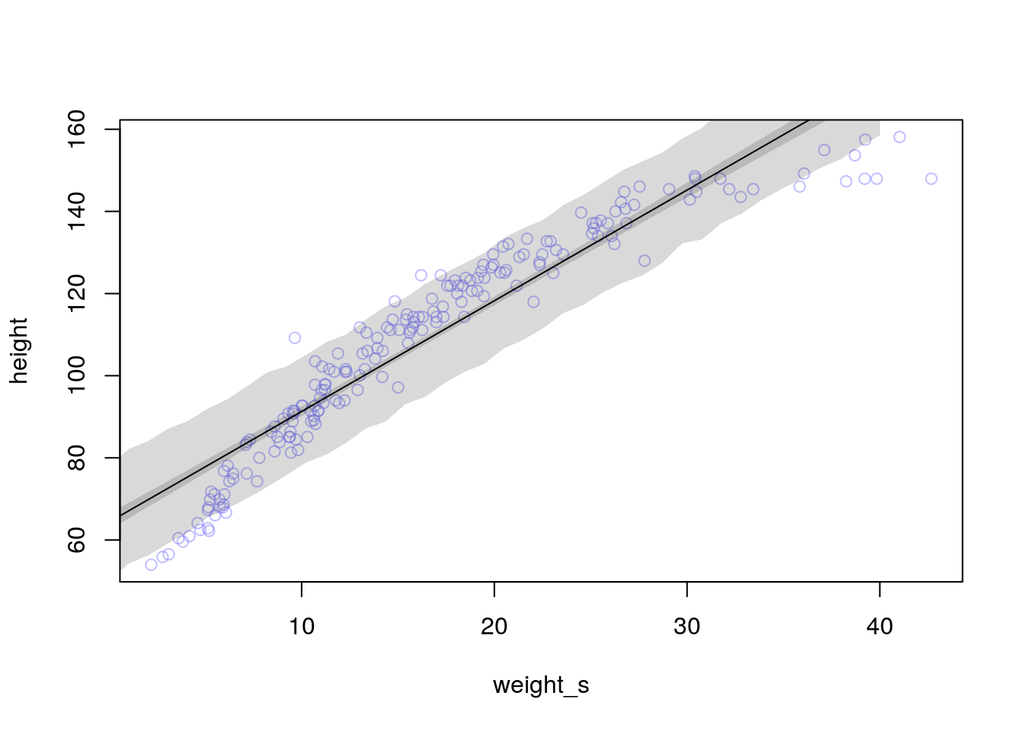

```r
weight.seq <- seq( from=0, to=40, length.out = 40)
pred_dat <- list(weight_s=weight.seq)
mu <- link(m4H2, data=pred_dat)
mu.mean <- apply( mu, 2, mean)
mu.PI <- apply( mu, 2, PI, prob=0.89)
sim.height <- sim(m4H2, data=pred_dat)
height.PI <- apply( sim.height, 2, PI, prob=0.89)


plot(height ~ weight_s, d3, col=col.alpha(rangi2,0.5))
lines( weight.seq, mu.mean)
shade( mu.PI, weight.seq)
shade( height.PI, weight.seq)
```

Want: (c) Critique the prediction.

Sol.:

The linear regression does a poor job in prediting the heights at lower and top end of the spectrum. A better model would be quadratic or cubic regression.

## 4H3.

Given: Entire Howell1 data.

Want: (a) Fit model with
$$h_i \sim Normal(\mu_i, \sigma)\\
\mu_i = \alpha + \beta log(w_i)\\
\alpha \sim Normal(178, 20)\\
\beta \sim Log-Normal(0,1)\\
\sigma \sim Uniform(50)$$
Sol.:

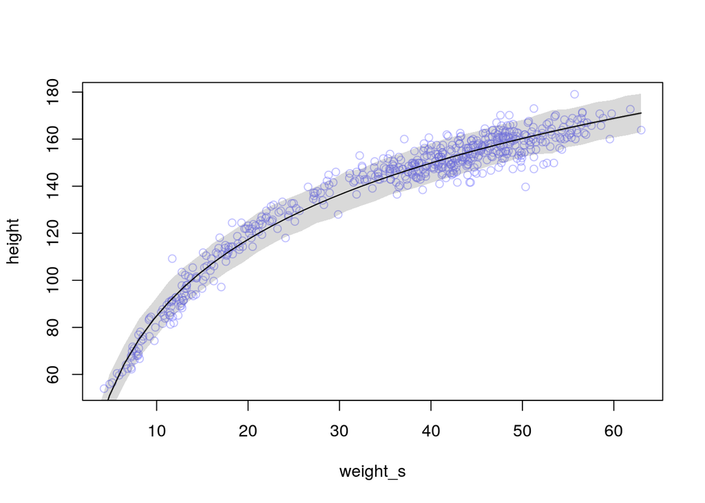

```r
xbar <- mean(d$weight)

# fit model
d4 <- d
#d4$weight_s <- (d4$weight - mean(d4$weight) / sd(d4$weight))
d4$weight_s <- d4$weight
m4H3 <- quap(
  alist(
    height ~ dnorm( mu , sigma ) ,
    mu <- a + b*log( weight_s ) ,
    a ~ dnorm( 178 , 20 ) ,
    b ~ dlnorm( 0 , 1 ) ,
    sigma ~ dunif( 0 , 50 )
  ) , data=d4 )

max_weight <- max(d4$weight_s)
weight.seq <- seq( from=0, to=max_weight, length.out = 40)
pred_dat <- list(weight_s=weight.seq)
mu <- link(m4H3, data=pred_dat)
mu.mean <- apply( mu, 2, mean)
mu.PI <- apply( mu, 2, PI, prob=0.89)
sim.height <- sim(m4H3, data=pred_dat)
height.PI <- apply( sim.height, 2, PI, prob=0.89)


plot(height ~ weight_s, d4, col=col.alpha(rangi2,0.5))
lines( weight.seq, mu.mean)
shade( mu.PI, weight.seq)
shade( height.PI, weight.seq)
```

Although the weights are not standardized the plot indecates the model fits the data quite well.

Want: (b) Plot predicted mean, 97 % interval for mean, 97 % interval for data.

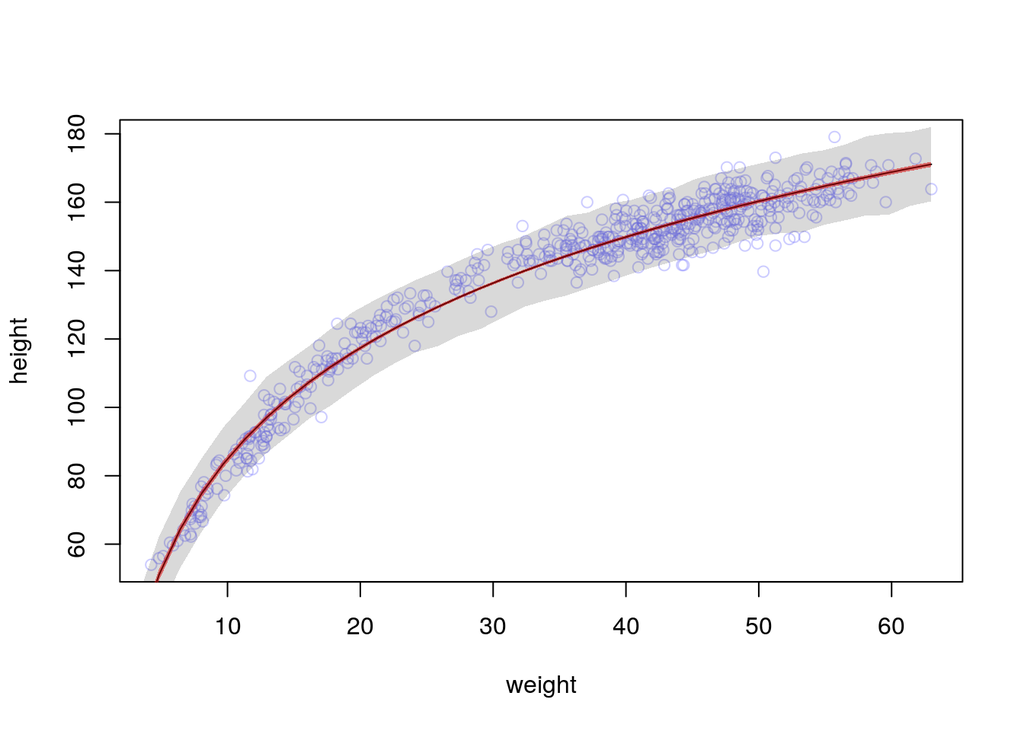

```r
plot( height ~ weight, data=d4, col=col.alpha(rangi2, 0.4))

max_weight <- max(d4$weight_s)
weight.seq <- seq( from=0, to=max_weight, length.out = 40)
pred_dat <- list(weight_s=weight.seq)
mu <- link(m4H3, data=pred_dat)
mu.mean <- apply( mu, 2, mean)
mu.PI <- apply( mu, 2, PI, prob=0.97)
sim.height <- sim(m4H3, data=pred_dat)
height.PI <- apply( sim.height, 2, PI, prob=0.97)


lines( weight.seq, mu.mean)
shade( mu.PI, weight.seq, col = col.alpha("red",0.5))
shade( height.PI, weight.seq)
```

## 4H4.

Given: Entire Howell1 data.

Want: Plot prior predictive distribution for the polynomial regression model. Modify the prior distribution so that the values stay inside the biologically reasonable range.

Sol.:

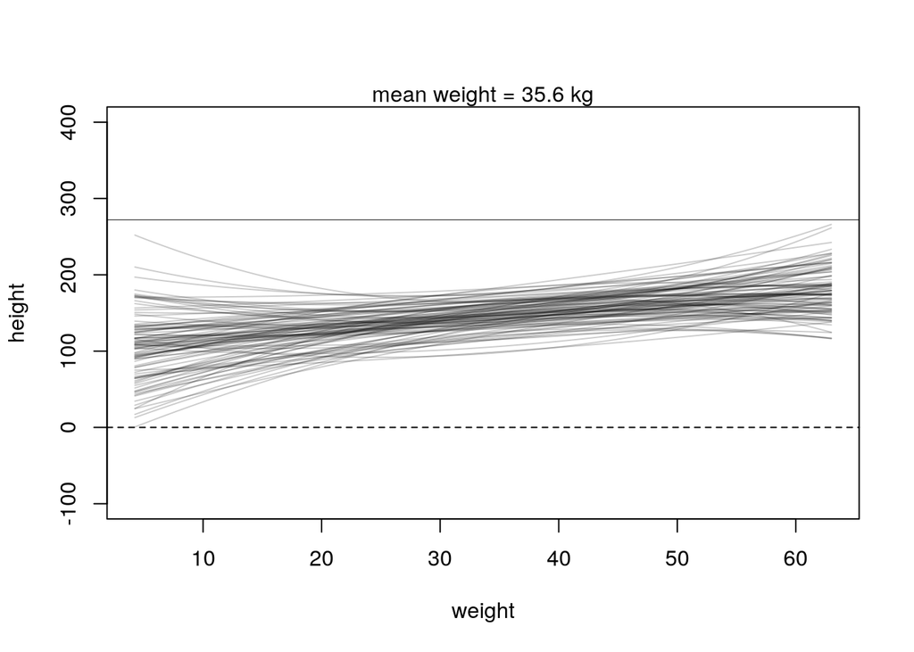

```r
max_weight <- max(d4$weight)
weight_s <- seq( from=0, to=max_weight, length.out = 40)
weight_s2 <- weight_s^2

N <- 100
a <- rnorm(N, 150, 20)
b1 <- rlnorm(N,0,0.4)
b2 <- rnorm(N,0,0.04)
sigma <- runif(N, 0, 50)

plot( NULL , xlim=range(d4$weight) , ylim=c(-100,400) ,
    xlab="weight" , ylab="height" )
abline( h=0 , lty=2 )
abline( h=272 , lty=1 , lwd=0.5 )
mtext(sprintf("mean weight = %.1f kg", xbar) )
xbar <- mean(d4$weight)
for ( i in 1:N ) curve( a[i] + b1[i]*(x-xbar) + b2[i]*(x-xbar)^2 ,
    from=min(d4$weight) , to=max(d4$weight) , add=TRUE ,
    col=col.alpha("black",0.2) )
```